# Machine Learning Final ( IMDB Dataset Exploration)

## Problem Definition

### Context

The main task for the project evolves around doing sentiment analysis on the review dataset. This Natural language Processing problem aims to determine the sentiments and emotions expressed in the review. These emotions can be in form of textual data such as comments reviews or social media posts.

### Objective

For this project the objective is to perform sentiment analysis on IMDB dataset. This IMDB dataset consists of 50,000 reviews from the internet movie Database. Furthermore, dataset is split into two parts, 25,000 for train and 25,000 for testing. Finally,the dataset is classified into negative and positive reviews.

### Goal

Now in this project we will work on the negative and postive reviews by building a machine learning model that can accurately classify negative and positive reviews based on the content provided. To explain more about the sentiments, it is understood that positive reviews are supposed to express sense of satisfaction or approval whereas, the negative reviews consist of a critical viewpoint or dissatisfaction. In this project we are going to build a network and examine how the model performs on the given dataset and how it performs on the unseen dataset. Along with that we are going to use multiple techniques to see how we can mitigate the issue of overfitting in models.

#### Key Components

The key components of the project can be calssified into two where one is the input where we provide the model with the input data and the second is the output. The input willl include textual movie reviews and each review is represented as sequence of words. This data is going to be preprocessed to map the words into integer indices. The output for the model is going to be a binary classification that indicates whether the review is positive or negative.

#### Importance

The importance of this project revolves around its application. This can be in multiple domains such as understanding product reviews, customer feedback and user opinions. However, for this project the application will help us to understand movie reviews and how good our model is able to understand the sentiments to explore whether the movie was liked or disliked by people.

#### Challenges

- **Imbalanced Classes**: The model must perform well in classifying the sentiments even when the classes are imbalanced.
- **Overfitting/Underfitting**: The model must balance the complexity in order to avoid the overfitting where we will see the ability of the model how well it memorizes the data. Similarly, balance the Overfitting where the model fails to capture the data and therefore it effects the results. For IMDB dataset capturing and memorizing would mean understanding the sentiments and the words in a series of words to classify whether its negative or positive.
- **Generalization**: Along with working on the IMDB dataset, we must work on making sure that the dataset not only performs well on this dataset but performs good in unseen data as this will be crucial and the project will make sure it eveluates this aspect.

## Data Preparation

### Loading and Preprocessing ( IMDB Dataset )

The IMDB datset comes with keras package and the dataset is already preprocessed, which means that the words are converted into integers. This would be a better way to actually process and work on the dataset that is easier for the machine to understand. In the following code we are going to load 10,000 most frequently occuring words into the training dataset and the words that are rare will be ignored. The purpose of doing this is to make the process more efficient by making the data smaller and easier to process.

Dependencies

```python
# pip install keras
# pip install tensorflow
# pip install matplotlib
```

```python
from keras.datasets import imdb

(train_data, train_labels), (test_data, test_labels) = imdb.load_data(
    num_words=10000)
```

Now in the code below we take train data to go through the array to see how the words are stored and we see that the words are actually preprocessed and are stored as integers. Similarly, the train label array holds the abels for the classes. Which in our case will be positive or negative reviews and therefore we can also see that. Finally, we ensure by checking tha maximum amount of words that they are restricted below 10,000 words and do not exceed this limit. Controlling the size also helps in handling computational complexities and rare words might introduce noise and therefore are discarded.

```python
train_data[0]
```

```
[1,
 14,
 22,
 16,
 43,
 530,
 973,
 1622,
 1385,
 65,
 458,
 4468,
 66,
 3941,
 4,
 173,
 36,
 256,
 5,
 25,
 100,
 43,
 838,
 112,
 50,
 670,
 2,
 9,
 35,
 480,
 284,
 5,
 150,
 4,
 172,
 112,
 167,
 2,
 336,
 385,
```

[output cut: 163 more lines]

```
 12,
 16,
 283,
 5,
 16,
 4472,
 113,
 103,
 32,
 15,
 16,
 5345,
 19,
 178,
 32]
```

```python
train_labels[0]
```

```
1
```

```python
max([max(sequence) for sequence in train_data])
```

```
9999
```

As we discussed above that the data that we have is preprocessed and does not store the words, therefore to convert the integers back to words we can use the code below. The way the code works is by fetching the word index mapping using the 'imdb.get_word_index()' and then it creates a reverse mapping from index to word.

```python
# code to decode the reviews back into english
# word_index = imdb.get_word_index()                                    #1
# reverse_word_index = dict(
#     [(value, key) for (key, value) in word_index.items()])            #2
# decoded_review = ' '.join(
#     [reverse_word_index.get(i - 3, '?') for i in train_data[0]])      #3
```

### Vectorization

The next major step in creating the model is converting the word indices to binary matrices. The vectorization process is crucial as neural networks cannot take integers as an input and therefore they require numerical input. This process transforms the data into a format that is suitable for the neural network and enables us to feed it to the network. Similarly, another task that we perform here is creating binary matrix representation. Here each row in the matrix corresponds to a review , and the columns represent a word in the vocabulary. For example , the presence of 1 in the matrix would represent presence of a word in the matrix. Now the reason we do this is make the word handling efficient in the presence or absense of reviews as it simplifies the input format.

```python
import numpy as np

def vectorize_sequences(sequences, dimension=10000):
    results = np.zeros((len(sequences), dimension))        #1
    for i, sequence in enumerate(sequences):
        results[i, sequence] = 1.                          #2
    return results

x_train = vectorize_sequences(train_data)                  #3
x_test = vectorize_sequences(test_data)
```

Now when we examine the way the samples look below, we can see we can see that we see that the value at each position indicates the presence of word and the 0 for absence of any word in the first training sample.

```python
x_train[0]
```

```
array([0., 1., 1., ..., 0., 0., 0.])
```

```python
y_train = np.asarray(train_labels).astype('float32')
y_test = np.asarray(test_labels).astype('float32')
```

Now in the code above , these two variables basically contain the sentiment label of the reviews , and that would mean 1's and 0's which means either a positive or negative review. In this code the we convert these labels into numpy arrays which are more versatile for numerical operations. Finally, the integer labels are converted into floating point numbers and this is important as the final layer of the neural network will use the sigmoid activation function which basically expects input labels into floating point format.

### Building the Network

Now in this part we will build the network now that we have the sequences ready. The input data consists of vectors which are the word sequences and the labels in the data are scalars which means 0's or 1's. Now here we pick our network architecture. This is a stack of fully dense Layers. The architecture consists of two intermeddiate layers, each with 16 hidden units and a third layer for output. The intermediate layers use the Rectified Linear Unit which is also known as relu which is the activation function. Then, the final layer uses a sigmoid activation function that provides us with a probability score between 0 and 1.  
Similarly, its important to understand the hidden units. As in each layer these units determine the dimensionality of the representation spaces which in out case is 16. More hidden layers allow the network to process and learn with more complex respresentations, However this comes at a cost of increasing the computational cost. Additionally, the weight matrix for each layer has a shape, which in our case projects the input data into a 16 dimensional space.  
Another main aspect of this network is that we are using two main activation functions, which are relu and sigmoid . The relu function is used in the intermediate layers to introduce the non linearity by making the negative values zero. The sigmoid function in the end will provide the probability of the interpretation.

```python
from keras import models
from keras import layers
```

```python
model = models.Sequential()
model.add(layers.Dense(16, activation='relu', input_shape=(10000,)))
model.add(layers.Dense(16, activation='relu'))
model.add(layers.Dense(1, activation='sigmoid'))
```

#### Choosing the loss function and the Optimiser.

Now that we have the output from the last layer the problem here is that the output is the probabilities created formthe sigmoid function which is binary. Now , we need a loss function, To move forward we picked the binary crossentropy function over the other options. The reason we went forward with this function is because this function measures the distance between the probabilty distributions, Now in our case it will basically quantify the difference between the actual distribution values and the ones that are predicted. Additionally, we picked an optimiser RMSprop which is an algorithm which is good at adapting to the learning rates for each of the parameters individually.

```python
model.compile(optimizer='rmsprop',
              loss='binary_crossentropy',
              metrics=['accuracy'])
```

#### Configuring the optimiser

This process involves customising the parameters of the optimiser. Which in our case would be adding the learning rate 'lr' of 0.001. This is responsible for allowing fine tuning of this optimisers behaviour.

```python
from keras import optimizers

model.compile(optimizer=optimizers.RMSprop(learning_rate=0.001),
              loss='binary_crossentropy',
              metrics=['accuracy'])
```

#### Using Custom Losses and Metrics:

```python
from keras import losses
from keras import metrics

model.compile(optimizer=optimizers.RMSprop(learning_rate=0.001),
              loss=losses.binary_crossentropy,
              metrics=[metrics.binary_accuracy])
```

## Validating your approach

The next crucial part is validating the work that we have done above. Now the aim of this part is to assess the performance of the data that we could not see in the training. Additionally, this will allow us to identify issues such as overfitting and underfitting and this will provide insights to examine whether the model can work on unseen data. In the code below , we have created a validation set that sets 10,000 samples aside from the original data. To monitor the performance of the model we have seperated the datset which is x_val and y_val.

```python
x_val = x_train[:10000]
partial_x_train = x_train[10000:]
y_val = y_train[:10000]
partial_y_train = y_train[10000:]
```

### Training your model

```python
model.compile(optimizer='rmsprop',
              loss='binary_crossentropy',
              metrics=['acc'])

imdb_history = model.fit(partial_x_train,
                    partial_y_train,
                    epochs=20,
                    batch_size=512,
                    validation_data=(x_val, y_val))
```

```
30/30 ━━━━━━━━━━━━━━━━━━━━ 2s 48ms/step - acc: 0.6794 - loss: 0.6053 - val_acc: 0.8605 - val_loss: 0.3992
30/30 ━━━━━━━━━━━━━━━━━━━━ 1s 26ms/step - acc: 0.8949 - loss: 0.3351 - val_acc: 0.8618 - val_loss: 0.3437
30/30 ━━━━━━━━━━━━━━━━━━━━ 1s 23ms/step - acc: 0.9221 - loss: 0.2455 - val_acc: 0.8858 - val_loss: 0.2893
30/30 ━━━━━━━━━━━━━━━━━━━━ 1s 20ms/step - acc: 0.9411 - loss: 0.1911 - val_acc: 0.8903 - val_loss: 0.2762
30/30 ━━━━━━━━━━━━━━━━━━━━ 1s 16ms/step - acc: 0.9498 - loss: 0.1573 - val_acc: 0.8885 - val_loss: 0.2783
30/30 ━━━━━━━━━━━━━━━━━━━━ 1s 17ms/step - acc: 0.9608 - loss: 0.1294 - val_acc: 0.8851 - val_loss: 0.2860
30/30 ━━━━━━━━━━━━━━━━━━━━ 1s 16ms/step - acc: 0.9662 - loss: 0.1127 - val_acc: 0.8871 - val_loss: 0.3015
30/30 ━━━━━━━━━━━━━━━━━━━━ 1s 19ms/step - acc: 0.9717 - loss: 0.0978 - val_acc: 0.8715 - val_loss: 0.3396
30/30 ━━━━━━━━━━━━━━━━━━━━ 1s 18ms/step - acc: 0.9760 - loss: 0.0862 - val_acc: 0.8807 - val_loss: 0.3282
30/30 ━━━━━━━━━━━━━━━━━━━━ 1s 28ms/step - acc: 0.9824 - loss: 0.0722 - val_acc: 0.8824 - val_loss: 0.3438
30/30 ━━━━━━━━━━━━━━━━━━━━ 1s 26ms/step - acc: 0.9871 - loss: 0.0594 - val_acc: 0.8782 - val_loss: 0.3801
30/30 ━━━━━━━━━━━━━━━━━━━━ 1s 17ms/step - acc: 0.9901 - loss: 0.0495 - val_acc: 0.8725 - val_loss: 0.3893
30/30 ━━━━━━━━━━━━━━━━━━━━ 1s 29ms/step - acc: 0.9921 - loss: 0.0438 - val_acc: 0.8776 - val_loss: 0.4167
30/30 ━━━━━━━━━━━━━━━━━━━━ 1s 31ms/step - acc: 0.9911 - loss: 0.0413 - val_acc: 0.8716 - val_loss: 0.4314
30/30 ━━━━━━━━━━━━━━━━━━━━ 1s 15ms/step - acc: 0.9944 - loss: 0.0335 - val_acc: 0.8751 - val_loss: 0.4426
30/30 ━━━━━━━━━━━━━━━━━━━━ 1s 17ms/step - acc: 0.9952 - loss: 0.0294 - val_acc: 0.8745 - val_loss: 0.4645
30/30 ━━━━━━━━━━━━━━━━━━━━ 1s 19ms/step - acc: 0.9984 - loss: 0.0206 - val_acc: 0.8734 - val_loss: 0.4889
30/30 ━━━━━━━━━━━━━━━━━━━━ 1s 20ms/step - acc: 0.9980 - loss: 0.0199 - val_acc: 0.8600 - val_loss: 0.5949
30/30 ━━━━━━━━━━━━━━━━━━━━ 1s 25ms/step - acc: 0.9971 - loss: 0.0220 - val_acc: 0.8679 - val_loss: 0.5601
30/30 ━━━━━━━━━━━━━━━━━━━━ 1s 17ms/step - acc: 0.9971 - loss: 0.0190 - val_acc: 0.8698 - val_loss: 0.5588
```

#### Monitoring the markdown

Now after the model is trained we monitor the the training process and therefore in the code below it is seen that we look for the 'History' object which basically contains a dictionary with entries for training and validation metrics. These metrics will include the accuracy, loss , validation loss and validation accuracy.

```python
imdb_history_dict = imdb_history.history
imdb_history_dict.keys()
[u'acc', u'loss', u'val_acc', u'val_loss']
```

```
['acc', 'loss', 'val_acc', 'val_loss']
```

### Plotting Results

Finally , taking the results from the monitoring above we take both accuracy and loss to plot the results to analyse and assess. In the code below, the blue dots are going to represent the training loss while the solid blue line is going to represent the validation loss.

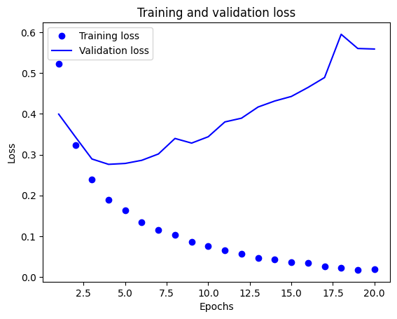

```python
# Plotting the training and validation loss
import matplotlib.pyplot as plt

history_dict = imdb_history.history
org_loss_values = imdb_history_dict['loss']
org_val_loss_values = imdb_history_dict['val_loss']
org_acc_values = imdb_history_dict['acc']

epochs = range(1, len(org_acc_values) + 1)

plt.plot(epochs, org_loss_values, 'bo', label='Training loss')           #1
plt.plot(epochs, org_val_loss_values, 'b', label='Validation loss')      #2
plt.title('Training and validation loss')
plt.xlabel('Epochs')
plt.ylabel('Loss')
plt.legend()

plt.show()
```

#### Observation

In the graph above we can see that the training loss consistently decreases with each epoch, this is exactly what we were expecting in the gradient decent optimization process. On the other side the validation shows an interesting pattern and the change in the line while the loss peaks at some epochs indicates potential overfitting.

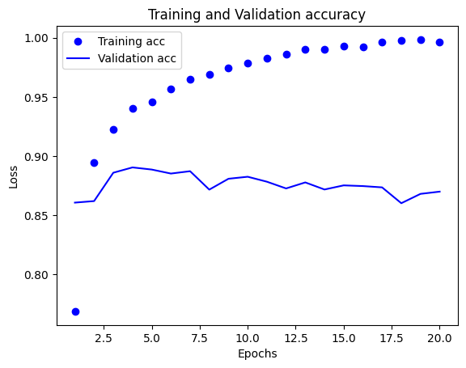

```python
# Plotting the training and validation accuracy

plt.clf()                                      #1
org_acc_values = imdb_history_dict['acc']
org_val_acc_values = imdb_history_dict['val_acc']

plt.plot(epochs, org_acc_values, 'bo', label='Training acc')
plt.plot(epochs, org_val_acc_values, 'b', label='Validation acc')
plt.title('Training and Validation accuracy')
plt.xlabel('Epochs')
plt.ylabel('Loss')
plt.legend()

plt.show()
```

#### Observation

In the training and validation accuracy graph, after each epoch we can see that the training accuracy improves. The problem is with the validation accuracy shows a peak in the 4th epoch which may make the model struggle in working with unseen and new data.

### Retraining the model from scratch

As we analyzed above while assessing the results, we saw that there was indication of overfitting in the model. Therefore we move on by training a new network from scratch for only four epochs and then evaluating whether we see any better results. The purpose of this step is to explore wheter stopping the training earlier helps the model to work better with unseen and new data. In the code below we have made some changes to the model. Now a new model is created that uses Sequential model from keras. This will consist two intermediate layers with 16 units. The model is compiled using the same loss function as before. The main change is in the training where we have performed the training for only four epochs with the batch size of 512. The results are stored in the result variable.

```python
# Retraining a model from scratch

model = models.Sequential()
model.add(layers.Dense(16, activation='relu', input_shape=(10000,)))
model.add(layers.Dense(16, activation='relu'))
model.add(layers.Dense(1, activation='sigmoid'))

model.compile(optimizer='rmsprop',
              loss='binary_crossentropy',
              metrics=['accuracy'])

model.fit(x_train, y_train, epochs=4, batch_size=512)
results = model.evaluate(x_test, y_test)
```

```
49/49 ━━━━━━━━━━━━━━━━━━━━ 1s 13ms/step - accuracy: 0.6769 - loss: 0.5835
49/49 ━━━━━━━━━━━━━━━━━━━━ 0s 9ms/step - accuracy: 0.9010 - loss: 0.3046
49/49 ━━━━━━━━━━━━━━━━━━━━ 1s 10ms/step - accuracy: 0.9245 - loss: 0.2224
49/49 ━━━━━━━━━━━━━━━━━━━━ 1s 16ms/step - accuracy: 0.9397 - loss: 0.1765
782/782 ━━━━━━━━━━━━━━━━━━━━ 1s 1ms/step - accuracy: 0.8820 - loss: 0.2886
```

```python
results
```

```
[0.28708890080451965, 0.8849599957466125]
```

Now if we look at the results the accuracy of the model has improved and has become 88 percent.

```python
model.predict(x_test)
```

```
782/782 ━━━━━━━━━━━━━━━━━━━━ 1s 970us/step
```

```
array([[0.19935024],
       [0.9958377 ],
       [0.8266147 ],
       ...,
       [0.11841566],
       [0.08287128],
       [0.4961572 ]], dtype=float32)
```

In the code above we are using the predict method to the test data. This generates predictions that indicate the positivity of reviews. As seen in the results , the output is an arrray of predicted values. Here each value ranges from 0 to 1. Similarly, we can also see that the model is able to provide varying degree of confidence for multiple samples. Here a higher confidence would mean something closer to 0 or 1 and a lower confidence of model would mean values that are between 0.6 and 0.4. Finally the model shows improvement over the last results by mitigating the issue of overfitting and providing improved accuracy. The results also mean that the model can be now used for unseen data.

## Further Exploring the techniques

Now we saw in the process above that we created a network, trained the model and assesed the results, we observed that the results shows overfitting adn therefore we came up with a simple solution of reducing epochs and that gave us improvement over the previous results. Now, we can use other techniques and analyze how we can improve the models performance and see if we can increase the accuracy of the model.

### Changing the Loss Function and Activation function

As we require multiple exploration of the model , its better to create a function that takes the values that we intend to change and then gives us result of the improvement and we can asses the changings in a better way. The main things that we need to change are the loss function, the activation function, the number of epochs and the test accuracy. Now another function that I am going to create is the results function. The purpose of creating this funcion is to store the results from the experiments that we carry out so we can store them. In the end we can use these results for comparison and see how the experiments affected the accuracy and loss of the model.

```python
# defining a dictionary to store the results
model_results = []
# function takes the details fo the experiement that
# is carried out and adds it into the model_results dictionary
def store_results(activate_func,loss_func,
                  num_ep, net_size,batch_size,
                  test_loss,test_acc):
    model_results.append({
        'Loss function': loss_func,
        'Activation': activate_func,
        'Epochs': num_ep,
        'Network Size': net_size,
        'Batch Size':  batch_size,
        'Loss': test_loss,
        'Accuracy': test_acc
    })
```

The function below will take the history object to display the results from the model. Here I have used similar implementation from the code that was used in the report above. Additionally we have added the validation losses values from the original imdb dataset. The purpose of doing this is to compare the resulst while we do experimentation.

```python
def plot_results(history):
    history_dict = history.history
    history_dict.keys()
    loss_values = history_dict['loss']
    val_loss_values = history_dict['val_loss']
    acc_values = history_dict['acc']
    acc_values = history_dict['acc']
    val_acc_values = history_dict['val_acc']
    epochs = range(1, len(acc_values) + 1)
    plt.figure(figsize=(12, 6))

    plt.subplot(1, 2, 1)

    plt.plot(epochs, loss_values, 'bo', label='Training loss')                      #1
    plt.plot(epochs, val_loss_values, 'b', label='Validation loss')                 #2
    #  here in the code I have made some modification
    # to limit the array of values to be equal
    #  to the length of the epochs of current model
    # so the plotting does not give any error
    plt.plot(epochs, org_val_loss_values[:len(loss_values)],
             'r', label='Original Validation loss')    #3

    plt.title('Training and validation loss')
    plt.xlabel('Epochs')
    plt.ylabel('Loss')
    plt.legend()

    # Plot training and validation accuracy
    plt.subplot(1, 2, 2)
    plt.plot(epochs, acc_values, 'bo', label='Training acc')
    plt.plot(epochs, val_acc_values, 'b', label='Validation acc')
    plt.plot(epochs, org_val_acc_values[:len(loss_values)],
             'r', label='Original Validation acc')
    plt.title('Training and Validation accuracy')
    plt.xlabel('Epochs')
    plt.ylabel('Loss')
    plt.legend()

    plt.show()
```

The function below is the main function that is resposible for building the network and we are going to use the functions that we created above in this function. This function will also be changed and modified for experiments however the functions above will most likely stay the same.

```python
def train_model_results(act_function,loss_function,
                        num_epochs, net_size, batch):
    x_value = x_train[:10000]
    partial_x_train_val = x_train[10000:]
    y_value = y_train[:10000]
    partial_y_train_value = y_train[10000:]
    model = models.Sequential()
    model.add(layers.Dense(net_size,
                           activation=act_function,
                           input_shape=(10000,)))
    model.add(layers.Dense(net_size, activation=act_function))
    model.add(layers.Dense(1, activation='sigmoid'))

    model.compile(optimizer='rmsprop',
                  loss=loss_function, metrics=['acc'])
    history = model.fit(partial_x_train_val, partial_y_train_value,
                        epochs=num_epochs, batch_size=batch,
                        validation_data=(x_value, y_value))
    results = model.evaluate(x_test, y_test)
    #  storing the results in the dictionary
    store_results(act_function,loss_function,
                  num_epochs, net_size,batch,
                  results[0], results[1])
    # Printing the results along with every model
    print(
        f'Activation Function : {act_function} Loss Function : {loss_function} Number of Epochs: {num_epochs}')
    print(f'Loss Test : {results[0]} Accuracy Test : {results[1]}')
    plot_results(history)
```

#### Testing the function we created

```
30/30 ━━━━━━━━━━━━━━━━━━━━ 4s 116ms/step - acc: 0.6774 - loss: 0.6153 - val_acc: 0.8629 - val_loss: 0.4179
30/30 ━━━━━━━━━━━━━━━━━━━━ 1s 29ms/step - acc: 0.8851 - loss: 0.3667 - val_acc: 0.8798 - val_loss: 0.3285
30/30 ━━━━━━━━━━━━━━━━━━━━ 1s 25ms/step - acc: 0.9182 - loss: 0.2638 - val_acc: 0.8901 - val_loss: 0.2881
30/30 ━━━━━━━━━━━━━━━━━━━━ 1s 19ms/step - acc: 0.9317 - loss: 0.2082 - val_acc: 0.8786 - val_loss: 0.2971
30/30 ━━━━━━━━━━━━━━━━━━━━ 1s 26ms/step - acc: 0.9471 - loss: 0.1720 - val_acc: 0.8878 - val_loss: 0.2766
30/30 ━━━━━━━━━━━━━━━━━━━━ 1s 18ms/step - acc: 0.9578 - loss: 0.1404 - val_acc: 0.8749 - val_loss: 0.3080
30/30 ━━━━━━━━━━━━━━━━━━━━ 1s 18ms/step - acc: 0.9623 - loss: 0.1222 - val_acc: 0.8868 - val_loss: 0.2937
30/30 ━━━━━━━━━━━━━━━━━━━━ 1s 19ms/step - acc: 0.9713 - loss: 0.1021 - val_acc: 0.8853 - val_loss: 0.3047
30/30 ━━━━━━━━━━━━━━━━━━━━ 1s 21ms/step - acc: 0.9753 - loss: 0.0902 - val_acc: 0.8839 - val_loss: 0.3160
30/30 ━━━━━━━━━━━━━━━━━━━━ 1s 19ms/step - acc: 0.9814 - loss: 0.0762 - val_acc: 0.8810 - val_loss: 0.3369
30/30 ━━━━━━━━━━━━━━━━━━━━ 1s 23ms/step - acc: 0.9849 - loss: 0.0662 - val_acc: 0.8788 - val_loss: 0.3498
30/30 ━━━━━━━━━━━━━━━━━━━━ 1s 18ms/step - acc: 0.9897 - loss: 0.0537 - val_acc: 0.8718 - val_loss: 0.3866
30/30 ━━━━━━━━━━━━━━━━━━━━ 1s 23ms/step - acc: 0.9932 - loss: 0.0456 - val_acc: 0.8713 - val_loss: 0.4023
30/30 ━━━━━━━━━━━━━━━━━━━━ 1s 30ms/step - acc: 0.9946 - loss: 0.0380 - val_acc: 0.8746 - val_loss: 0.4131
30/30 ━━━━━━━━━━━━━━━━━━━━ 1s 23ms/step - acc: 0.9941 - loss: 0.0335 - val_acc: 0.8737 - val_loss: 0.4294
30/30 ━━━━━━━━━━━━━━━━━━━━ 1s 45ms/step - acc: 0.9971 - loss: 0.0261 - val_acc: 0.8727 - val_loss: 0.4497
30/30 ━━━━━━━━━━━━━━━━━━━━ 2s 54ms/step - acc: 0.9977 - loss: 0.0208 - val_acc: 0.8725 - val_loss: 0.4683
30/30 ━━━━━━━━━━━━━━━━━━━━ 1s 22ms/step - acc: 0.9989 - loss: 0.0164 - val_acc: 0.8709 - val_loss: 0.4903
30/30 ━━━━━━━━━━━━━━━━━━━━ 1s 25ms/step - acc: 0.9979 - loss: 0.0182 - val_acc: 0.8694 - val_loss: 0.5115
30/30 ━━━━━━━━━━━━━━━━━━━━ 1s 32ms/step - acc: 0.9991 - loss: 0.0118 - val_acc: 0.8709 - val_loss: 0.5348
782/782 ━━━━━━━━━━━━━━━━━━━━ 2s 2ms/step - acc: 0.8572 - loss: 0.5879
Activation Function : relu Loss Function : binary_crossentropy Number of Epochs: 20
Loss Test : 0.5725686550140381 Accuracy Test : 0.860480010509491
```

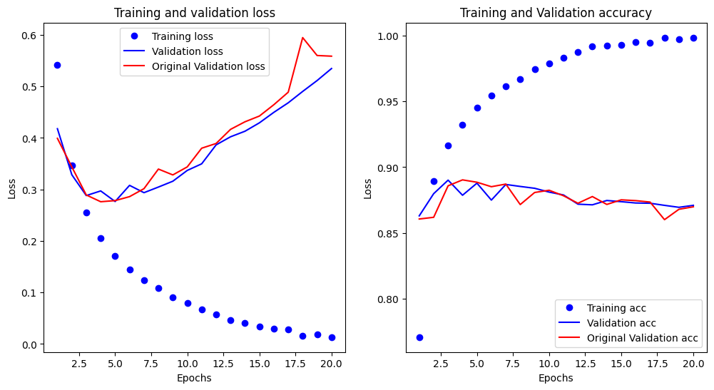

```python
# testing the function we made by using the configuration from the report above
train_model_results('relu','binary_crossentropy', 20, 16, 512 )
```

### Changing the Batch Size of the Network

Now as we can see that our function is ready and therefore we can start by changing parameters and functions in the model to assess the results.

```
118/118 ━━━━━━━━━━━━━━━━━━━━ 3s 17ms/step - acc: 0.7700 - loss: 0.5243 - val_acc: 0.8758 - val_loss: 0.3129
118/118 ━━━━━━━━━━━━━━━━━━━━ 1s 12ms/step - acc: 0.9231 - loss: 0.2170 - val_acc: 0.8905 - val_loss: 0.2745
118/118 ━━━━━━━━━━━━━━━━━━━━ 1s 9ms/step - acc: 0.9458 - loss: 0.1546 - val_acc: 0.8841 - val_loss: 0.2933
118/118 ━━━━━━━━━━━━━━━━━━━━ 1s 9ms/step - acc: 0.9592 - loss: 0.1203 - val_acc: 0.8617 - val_loss: 0.4018
118/118 ━━━━━━━━━━━━━━━━━━━━ 1s 9ms/step - acc: 0.9720 - loss: 0.0918 - val_acc: 0.8780 - val_loss: 0.3581
118/118 ━━━━━━━━━━━━━━━━━━━━ 1s 8ms/step - acc: 0.9773 - loss: 0.0696 - val_acc: 0.8707 - val_loss: 0.4105
118/118 ━━━━━━━━━━━━━━━━━━━━ 1s 8ms/step - acc: 0.9825 - loss: 0.0546 - val_acc: 0.8723 - val_loss: 0.4736
118/118 ━━━━━━━━━━━━━━━━━━━━ 1s 7ms/step - acc: 0.9900 - loss: 0.0392 - val_acc: 0.8709 - val_loss: 0.5128
118/118 ━━━━━━━━━━━━━━━━━━━━ 1s 8ms/step - acc: 0.9926 - loss: 0.0276 - val_acc: 0.8687 - val_loss: 0.5584
118/118 ━━━━━━━━━━━━━━━━━━━━ 1s 9ms/step - acc: 0.9940 - loss: 0.0207 - val_acc: 0.8481 - val_loss: 0.7040
118/118 ━━━━━━━━━━━━━━━━━━━━ 1s 9ms/step - acc: 0.9956 - loss: 0.0163 - val_acc: 0.8661 - val_loss: 0.7204
118/118 ━━━━━━━━━━━━━━━━━━━━ 1s 7ms/step - acc: 0.9979 - loss: 0.0090 - val_acc: 0.8660 - val_loss: 0.7846
118/118 ━━━━━━━━━━━━━━━━━━━━ 1s 8ms/step - acc: 0.9987 - loss: 0.0065 - val_acc: 0.8633 - val_loss: 0.9187
118/118 ━━━━━━━━━━━━━━━━━━━━ 1s 11ms/step - acc: 0.9993 - loss: 0.0042 - val_acc: 0.8667 - val_loss: 0.9021
118/118 ━━━━━━━━━━━━━━━━━━━━ 1s 8ms/step - acc: 0.9996 - loss: 0.0028 - val_acc: 0.8635 - val_loss: 0.9496
118/118 ━━━━━━━━━━━━━━━━━━━━ 1s 9ms/step - acc: 1.0000 - loss: 0.0012 - val_acc: 0.8645 - val_loss: 1.0508
118/118 ━━━━━━━━━━━━━━━━━━━━ 2s 14ms/step - acc: 0.9999 - loss: 9.7185e-04 - val_acc: 0.8642 - val_loss: 1.1005
118/118 ━━━━━━━━━━━━━━━━━━━━ 1s 7ms/step - acc: 1.0000 - loss: 4.5911e-04 - val_acc: 0.8644 - val_loss: 1.1826
118/118 ━━━━━━━━━━━━━━━━━━━━ 1s 7ms/step - acc: 0.9999 - loss: 3.7513e-04 - val_acc: 0.8601 - val_loss: 1.2363
118/118 ━━━━━━━━━━━━━━━━━━━━ 1s 9ms/step - acc: 1.0000 - loss: 2.0694e-04 - val_acc: 0.8633 - val_loss: 1.3007
782/782 ━━━━━━━━━━━━━━━━━━━━ 1s 1ms/step - acc: 0.8473 - loss: 1.4418
Activation Function : relu Loss Function : binary_crossentropy Number of Epochs: 20
Loss Test : 1.3985652923583984 Accuracy Test : 0.8500400185585022
```

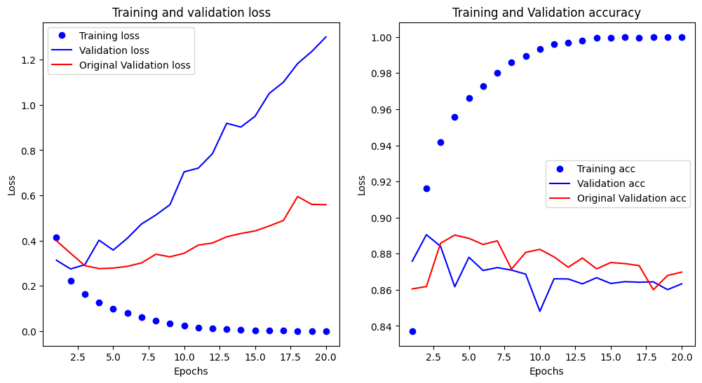

```python
train_model_results('relu','binary_crossentropy', 20, 16, 128 )
```

```
15/15 ━━━━━━━━━━━━━━━━━━━━ 4s 160ms/step - acc: 0.6290 - loss: 0.6619 - val_acc: 0.7952 - val_loss: 0.5551
15/15 ━━━━━━━━━━━━━━━━━━━━ 2s 101ms/step - acc: 0.8418 - loss: 0.5075 - val_acc: 0.8577 - val_loss: 0.4356
15/15 ━━━━━━━━━━━━━━━━━━━━ 1s 59ms/step - acc: 0.8878 - loss: 0.3916 - val_acc: 0.8756 - val_loss: 0.3676
15/15 ━━━━━━━━━━━━━━━━━━━━ 1s 71ms/step - acc: 0.9082 - loss: 0.3177 - val_acc: 0.8826 - val_loss: 0.3275
15/15 ━━━━━━━━━━━━━━━━━━━━ 1s 41ms/step - acc: 0.9150 - loss: 0.2733 - val_acc: 0.8854 - val_loss: 0.3046
15/15 ━━━━━━━━━━━━━━━━━━━━ 1s 50ms/step - acc: 0.9297 - loss: 0.2355 - val_acc: 0.8881 - val_loss: 0.2899
15/15 ━━━━━━━━━━━━━━━━━━━━ 1s 58ms/step - acc: 0.9354 - loss: 0.2093 - val_acc: 0.8853 - val_loss: 0.2864
15/15 ━━━━━━━━━━━━━━━━━━━━ 1s 83ms/step - acc: 0.9396 - loss: 0.1869 - val_acc: 0.8885 - val_loss: 0.2768
15/15 ━━━━━━━━━━━━━━━━━━━━ 2s 160ms/step - acc: 0.9442 - loss: 0.1748 - val_acc: 0.8844 - val_loss: 0.2858
15/15 ━━━━━━━━━━━━━━━━━━━━ 1s 39ms/step - acc: 0.9522 - loss: 0.1566 - val_acc: 0.8834 - val_loss: 0.2874
15/15 ━━━━━━━━━━━━━━━━━━━━ 1s 57ms/step - acc: 0.9602 - loss: 0.1411 - val_acc: 0.8864 - val_loss: 0.2783
15/15 ━━━━━━━━━━━━━━━━━━━━ 1s 55ms/step - acc: 0.9624 - loss: 0.1322 - val_acc: 0.8866 - val_loss: 0.2818
15/15 ━━━━━━━━━━━━━━━━━━━━ 1s 46ms/step - acc: 0.9651 - loss: 0.1212 - val_acc: 0.8751 - val_loss: 0.3154
15/15 ━━━━━━━━━━━━━━━━━━━━ 1s 49ms/step - acc: 0.9676 - loss: 0.1158 - val_acc: 0.8842 - val_loss: 0.2938
15/15 ━━━━━━━━━━━━━━━━━━━━ 1s 50ms/step - acc: 0.9702 - loss: 0.1058 - val_acc: 0.8842 - val_loss: 0.2987
15/15 ━━━━━━━━━━━━━━━━━━━━ 1s 66ms/step - acc: 0.9758 - loss: 0.0946 - val_acc: 0.8764 - val_loss: 0.3191
15/15 ━━━━━━━━━━━━━━━━━━━━ 1s 57ms/step - acc: 0.9777 - loss: 0.0893 - val_acc: 0.8837 - val_loss: 0.3208
15/15 ━━━━━━━━━━━━━━━━━━━━ 1s 45ms/step - acc: 0.9791 - loss: 0.0860 - val_acc: 0.8768 - val_loss: 0.3303
15/15 ━━━━━━━━━━━━━━━━━━━━ 1s 39ms/step - acc: 0.9794 - loss: 0.0778 - val_acc: 0.8764 - val_loss: 0.3367
15/15 ━━━━━━━━━━━━━━━━━━━━ 1s 42ms/step - acc: 0.9844 - loss: 0.0698 - val_acc: 0.8666 - val_loss: 0.3830
782/782 ━━━━━━━━━━━━━━━━━━━━ 1s 979us/step - acc: 0.8538 - loss: 0.4176
Activation Function : relu Loss Function : binary_crossentropy Number of Epochs: 20
Loss Test : 0.41648444533348083 Accuracy Test : 0.8557999730110168
```

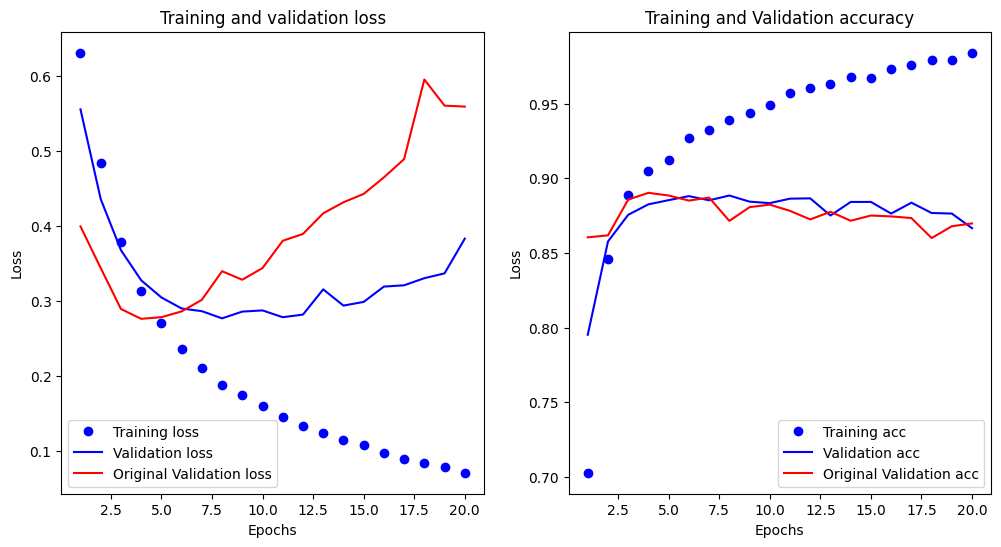

```python
train_model_results('relu','binary_crossentropy', 20, 16, 1024 )
```

### Evaluation

By changing batch sizes, we were able to see drastic changes in both limits. By using a lower batch size in the first experiment we saw that tha validation loss increased to a way higher value and it basically got overfit right from the start. However, by using a bigger batch size we were able to see a way lower validation loss. Additionally, a higher batch size also showed a more stable and straighter line. The model got overfit way later as compared to the original model.

#### Changing the Loss function to mean_squared_error

```
30/30 ━━━━━━━━━━━━━━━━━━━━ 3s 65ms/step - acc: 0.6937 - loss: 0.2056 - val_acc: 0.8636 - val_loss: 0.1231
30/30 ━━━━━━━━━━━━━━━━━━━━ 1s 19ms/step - acc: 0.8907 - loss: 0.1034 - val_acc: 0.8820 - val_loss: 0.0937
30/30 ━━━━━━━━━━━━━━━━━━━━ 1s 20ms/step - acc: 0.9190 - loss: 0.0716 - val_acc: 0.8651 - val_loss: 0.0984
30/30 ━━━━━━━━━━━━━━━━━━━━ 1s 22ms/step - acc: 0.9332 - loss: 0.0576 - val_acc: 0.8865 - val_loss: 0.0839
30/30 ━━━━━━━━━━━━━━━━━━━━ 1s 19ms/step - acc: 0.9448 - loss: 0.0465 - val_acc: 0.8859 - val_loss: 0.0837
30/30 ━━━━━━━━━━━━━━━━━━━━ 1s 20ms/step - acc: 0.9552 - loss: 0.0387 - val_acc: 0.8784 - val_loss: 0.0905
30/30 ━━━━━━━━━━━━━━━━━━━━ 1s 28ms/step - acc: 0.9660 - loss: 0.0314 - val_acc: 0.8822 - val_loss: 0.0887
30/30 ━━━━━━━━━━━━━━━━━━━━ 1s 27ms/step - acc: 0.9746 - loss: 0.0252 - val_acc: 0.8711 - val_loss: 0.1001
30/30 ━━━━━━━━━━━━━━━━━━━━ 1s 21ms/step - acc: 0.9783 - loss: 0.0214 - val_acc: 0.8748 - val_loss: 0.0965
30/30 ━━━━━━━━━━━━━━━━━━━━ 1s 17ms/step - acc: 0.9809 - loss: 0.0190 - val_acc: 0.8779 - val_loss: 0.0968
30/30 ━━━━━━━━━━━━━━━━━━━━ 1s 19ms/step - acc: 0.9842 - loss: 0.0160 - val_acc: 0.8776 - val_loss: 0.0992
30/30 ━━━━━━━━━━━━━━━━━━━━ 1s 20ms/step - acc: 0.9850 - loss: 0.0155 - val_acc: 0.8769 - val_loss: 0.1000
30/30 ━━━━━━━━━━━━━━━━━━━━ 1s 24ms/step - acc: 0.9878 - loss: 0.0119 - val_acc: 0.8720 - val_loss: 0.1033
30/30 ━━━━━━━━━━━━━━━━━━━━ 1s 26ms/step - acc: 0.9875 - loss: 0.0129 - val_acc: 0.8755 - val_loss: 0.1024
30/30 ━━━━━━━━━━━━━━━━━━━━ 1s 33ms/step - acc: 0.9908 - loss: 0.0097 - val_acc: 0.8759 - val_loss: 0.1033
30/30 ━━━━━━━━━━━━━━━━━━━━ 1s 24ms/step - acc: 0.9921 - loss: 0.0089 - val_acc: 0.8739 - val_loss: 0.1058
30/30 ━━━━━━━━━━━━━━━━━━━━ 1s 38ms/step - acc: 0.9853 - loss: 0.0137 - val_acc: 0.8739 - val_loss: 0.1056
30/30 ━━━━━━━━━━━━━━━━━━━━ 1s 33ms/step - acc: 0.9911 - loss: 0.0091 - val_acc: 0.8718 - val_loss: 0.1086
30/30 ━━━━━━━━━━━━━━━━━━━━ 1s 31ms/step - acc: 0.9924 - loss: 0.0082 - val_acc: 0.8728 - val_loss: 0.1072
30/30 ━━━━━━━━━━━━━━━━━━━━ 1s 31ms/step - acc: 0.9901 - loss: 0.0101 - val_acc: 0.8732 - val_loss: 0.1082
782/782 ━━━━━━━━━━━━━━━━━━━━ 1s 2ms/step - acc: 0.8568 - loss: 0.1213
Activation Function : tanh Loss Function : mean_squared_error Number of Epochs: 20
Loss Test : 0.1186409592628479 Accuracy Test : 0.8612800240516663
```

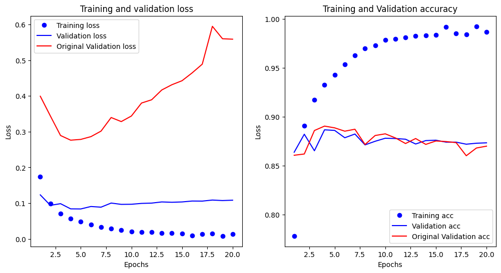

```python
train_model_results('tanh','mean_squared_error', 20, 16, 512 )
```

This experiment, did show some changes however the results are still not satisfactory as the accuracy is still the same as before but the loss value has drastically decreased. As seen in the graphs above, the original validation loss are way higher. This shows how lower the validation loss can get by just using a different loss and activation function. Now we move on by comparing the original results by 4 epochs instead of 20.

```
30/30 ━━━━━━━━━━━━━━━━━━━━ 3s 59ms/step - acc: 0.6700 - loss: 0.2186 - val_acc: 0.8500 - val_loss: 0.1433
30/30 ━━━━━━━━━━━━━━━━━━━━ 1s 21ms/step - acc: 0.8818 - loss: 0.1233 - val_acc: 0.8735 - val_loss: 0.1087
30/30 ━━━━━━━━━━━━━━━━━━━━ 1s 29ms/step - acc: 0.9077 - loss: 0.0888 - val_acc: 0.8758 - val_loss: 0.0989
30/30 ━━━━━━━━━━━━━━━━━━━━ 1s 30ms/step - acc: 0.9235 - loss: 0.0724 - val_acc: 0.8894 - val_loss: 0.0871
782/782 ━━━━━━━━━━━━━━━━━━━━ 1s 1ms/step - acc: 0.8827 - loss: 0.0912
Activation Function : relu Loss Function : mean_squared_error Number of Epochs: 4
Loss Test : 0.09076514840126038 Accuracy Test : 0.883080005645752
```

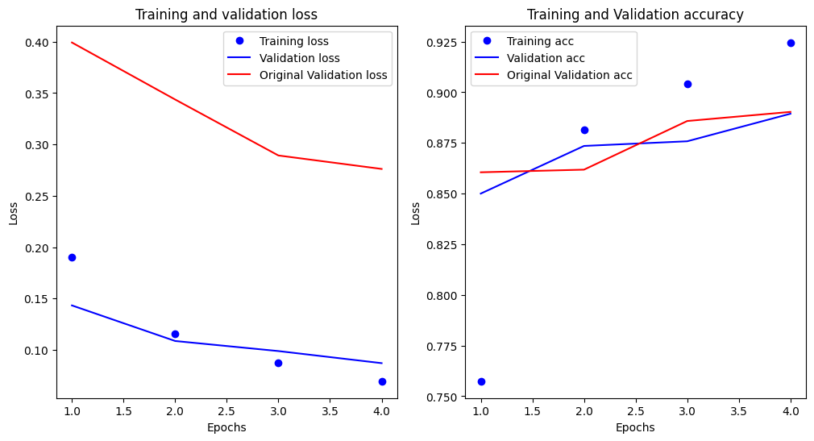

```python
train_model_results('relu','mean_squared_error', 4, 16, 512 )
```

By looking at the results above , we can clearly see how using less epochs gives us with lower loss values.

#### **Conslusion**

Assessing from the test results above we can see that changing Loss function allowed us to reduce the loss of the model however the activation function did not put any effect on the results.

### Comparison by the network Sizes

In this section we move forward by comparing the difference by changing the network sizes. Now as we know currently we are using 16 as a default value for network size. However, for the sake of exploration we use three different network sizes to compare and understand the effects of the modifications.

**Changing Network size to 4**

```
30/30 ━━━━━━━━━━━━━━━━━━━━ 2s 49ms/step - acc: 0.6867 - loss: 0.6254 - val_acc: 0.8529 - val_loss: 0.4752
30/30 ━━━━━━━━━━━━━━━━━━━━ 1s 15ms/step - acc: 0.8817 - loss: 0.4250 - val_acc: 0.8725 - val_loss: 0.3857
30/30 ━━━━━━━━━━━━━━━━━━━━ 1s 16ms/step - acc: 0.9099 - loss: 0.3273 - val_acc: 0.8774 - val_loss: 0.3367
30/30 ━━━━━━━━━━━━━━━━━━━━ 1s 25ms/step - acc: 0.9208 - loss: 0.2702 - val_acc: 0.8877 - val_loss: 0.3048
30/30 ━━━━━━━━━━━━━━━━━━━━ 1s 28ms/step - acc: 0.9319 - loss: 0.2304 - val_acc: 0.8904 - val_loss: 0.2880
30/30 ━━━━━━━━━━━━━━━━━━━━ 1s 32ms/step - acc: 0.9426 - loss: 0.1992 - val_acc: 0.8874 - val_loss: 0.2826
30/30 ━━━━━━━━━━━━━━━━━━━━ 1s 22ms/step - acc: 0.9465 - loss: 0.1804 - val_acc: 0.8931 - val_loss: 0.2739
30/30 ━━━━━━━━━━━━━━━━━━━━ 1s 24ms/step - acc: 0.9523 - loss: 0.1621 - val_acc: 0.8916 - val_loss: 0.2728
30/30 ━━━━━━━━━━━━━━━━━━━━ 1s 23ms/step - acc: 0.9571 - loss: 0.1445 - val_acc: 0.8867 - val_loss: 0.2825
30/30 ━━━━━━━━━━━━━━━━━━━━ 1s 25ms/step - acc: 0.9647 - loss: 0.1290 - val_acc: 0.8873 - val_loss: 0.2832
30/30 ━━━━━━━━━━━━━━━━━━━━ 1s 24ms/step - acc: 0.9700 - loss: 0.1189 - val_acc: 0.8834 - val_loss: 0.2909
30/30 ━━━━━━━━━━━━━━━━━━━━ 1s 23ms/step - acc: 0.9727 - loss: 0.1074 - val_acc: 0.8830 - val_loss: 0.2946
30/30 ━━━━━━━━━━━━━━━━━━━━ 1s 33ms/step - acc: 0.9769 - loss: 0.0958 - val_acc: 0.8847 - val_loss: 0.3012
30/30 ━━━━━━━━━━━━━━━━━━━━ 1s 22ms/step - acc: 0.9771 - loss: 0.0926 - val_acc: 0.8845 - val_loss: 0.3050
30/30 ━━━━━━━━━━━━━━━━━━━━ 1s 25ms/step - acc: 0.9817 - loss: 0.0792 - val_acc: 0.8816 - val_loss: 0.3164
30/30 ━━━━━━━━━━━━━━━━━━━━ 2s 72ms/step - acc: 0.9836 - loss: 0.0740 - val_acc: 0.8820 - val_loss: 0.3246
30/30 ━━━━━━━━━━━━━━━━━━━━ 1s 27ms/step - acc: 0.9847 - loss: 0.0691 - val_acc: 0.8806 - val_loss: 0.3505
30/30 ━━━━━━━━━━━━━━━━━━━━ 1s 35ms/step - acc: 0.9890 - loss: 0.0602 - val_acc: 0.8784 - val_loss: 0.3621
30/30 ━━━━━━━━━━━━━━━━━━━━ 1s 28ms/step - acc: 0.9900 - loss: 0.0537 - val_acc: 0.8800 - val_loss: 0.3644
30/30 ━━━━━━━━━━━━━━━━━━━━ 1s 22ms/step - acc: 0.9919 - loss: 0.0495 - val_acc: 0.8745 - val_loss: 0.3778
782/782 ━━━━━━━━━━━━━━━━━━━━ 1s 829us/step - acc: 0.8597 - loss: 0.4214
Activation Function : relu Loss Function : binary_crossentropy Number of Epochs: 20
Loss Test : 0.41424059867858887 Accuracy Test : 0.8635600209236145
```

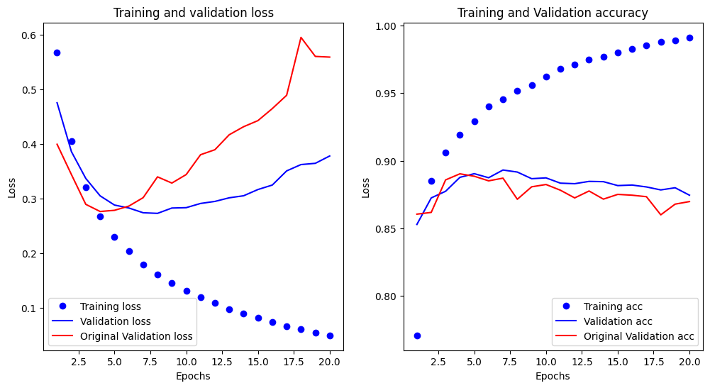

```python
train_model_results('relu','binary_crossentropy', 20, 4, 512 )
```

**Changing Network size to 16**

```
30/30 ━━━━━━━━━━━━━━━━━━━━ 3s 73ms/step - acc: 0.6961 - loss: 0.6054 - val_acc: 0.8625 - val_loss: 0.4108
30/30 ━━━━━━━━━━━━━━━━━━━━ 1s 35ms/step - acc: 0.8923 - loss: 0.3553 - val_acc: 0.8733 - val_loss: 0.3366
30/30 ━━━━━━━━━━━━━━━━━━━━ 1s 25ms/step - acc: 0.9172 - loss: 0.2623 - val_acc: 0.8871 - val_loss: 0.2909
30/30 ━━━━━━━━━━━━━━━━━━━━ 1s 36ms/step - acc: 0.9319 - loss: 0.2049 - val_acc: 0.8893 - val_loss: 0.2761
30/30 ━━━━━━━━━━━━━━━━━━━━ 1s 20ms/step - acc: 0.9476 - loss: 0.1701 - val_acc: 0.8850 - val_loss: 0.2853
30/30 ━━━━━━━━━━━━━━━━━━━━ 1s 20ms/step - acc: 0.9579 - loss: 0.1447 - val_acc: 0.8859 - val_loss: 0.2867
30/30 ━━━━━━━━━━━━━━━━━━━━ 1s 22ms/step - acc: 0.9666 - loss: 0.1191 - val_acc: 0.8871 - val_loss: 0.2867
30/30 ━━━━━━━━━━━━━━━━━━━━ 1s 21ms/step - acc: 0.9711 - loss: 0.1059 - val_acc: 0.8822 - val_loss: 0.3183
30/30 ━━━━━━━━━━━━━━━━━━━━ 1s 22ms/step - acc: 0.9756 - loss: 0.0901 - val_acc: 0.8848 - val_loss: 0.3184
30/30 ━━━━━━━━━━━━━━━━━━━━ 1s 21ms/step - acc: 0.9806 - loss: 0.0770 - val_acc: 0.8832 - val_loss: 0.3253
30/30 ━━━━━━━━━━━━━━━━━━━━ 1s 26ms/step - acc: 0.9877 - loss: 0.0627 - val_acc: 0.8817 - val_loss: 0.3536
30/30 ━━━━━━━━━━━━━━━━━━━━ 1s 20ms/step - acc: 0.9905 - loss: 0.0539 - val_acc: 0.8740 - val_loss: 0.3994
30/30 ━━━━━━━━━━━━━━━━━━━━ 1s 23ms/step - acc: 0.9911 - loss: 0.0466 - val_acc: 0.8749 - val_loss: 0.4084
30/30 ━━━━━━━━━━━━━━━━━━━━ 1s 22ms/step - acc: 0.9930 - loss: 0.0393 - val_acc: 0.8780 - val_loss: 0.3953
30/30 ━━━━━━━━━━━━━━━━━━━━ 1s 19ms/step - acc: 0.9960 - loss: 0.0291 - val_acc: 0.8782 - val_loss: 0.4175
30/30 ━━━━━━━━━━━━━━━━━━━━ 1s 20ms/step - acc: 0.9973 - loss: 0.0240 - val_acc: 0.8757 - val_loss: 0.4390
30/30 ━━━━━━━━━━━━━━━━━━━━ 1s 22ms/step - acc: 0.9982 - loss: 0.0199 - val_acc: 0.8751 - val_loss: 0.4578
30/30 ━━━━━━━━━━━━━━━━━━━━ 1s 22ms/step - acc: 0.9989 - loss: 0.0151 - val_acc: 0.8715 - val_loss: 0.4801
30/30 ━━━━━━━━━━━━━━━━━━━━ 1s 27ms/step - acc: 0.9990 - loss: 0.0129 - val_acc: 0.8740 - val_loss: 0.5041
30/30 ━━━━━━━━━━━━━━━━━━━━ 1s 31ms/step - acc: 0.9996 - loss: 0.0096 - val_acc: 0.8715 - val_loss: 0.5234
782/782 ━━━━━━━━━━━━━━━━━━━━ 1s 1ms/step - acc: 0.8568 - loss: 0.5743
Activation Function : relu Loss Function : binary_crossentropy Number of Epochs: 20
Loss Test : 0.5631202459335327 Accuracy Test : 0.8609200119972229
```

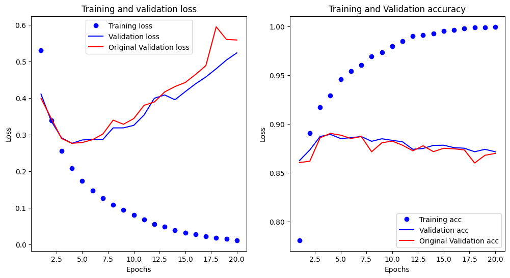

```python
train_model_results('relu','binary_crossentropy', 20, 16, 512 )
```

**Changing Network size to 512**

```
30/30 ━━━━━━━━━━━━━━━━━━━━ 5s 151ms/step - acc: 0.6491 - loss: 0.6538 - val_acc: 0.8308 - val_loss: 0.3919
30/30 ━━━━━━━━━━━━━━━━━━━━ 3s 105ms/step - acc: 0.8702 - loss: 0.3304 - val_acc: 0.8783 - val_loss: 0.2902
30/30 ━━━━━━━━━━━━━━━━━━━━ 4s 123ms/step - acc: 0.8998 - loss: 0.2520 - val_acc: 0.8897 - val_loss: 0.2683
30/30 ━━━━━━━━━━━━━━━━━━━━ 3s 93ms/step - acc: 0.9394 - loss: 0.1661 - val_acc: 0.8828 - val_loss: 0.2816
30/30 ━━━━━━━━━━━━━━━━━━━━ 3s 108ms/step - acc: 0.9474 - loss: 0.1387 - val_acc: 0.8829 - val_loss: 0.2899
30/30 ━━━━━━━━━━━━━━━━━━━━ 4s 138ms/step - acc: 0.9725 - loss: 0.0850 - val_acc: 0.8846 - val_loss: 0.3305
30/30 ━━━━━━━━━━━━━━━━━━━━ 5s 152ms/step - acc: 0.9736 - loss: 0.0829 - val_acc: 0.8833 - val_loss: 0.3551
30/30 ━━━━━━━━━━━━━━━━━━━━ 11s 329ms/step - acc: 0.9856 - loss: 0.0496 - val_acc: 0.8824 - val_loss: 0.3665
30/30 ━━━━━━━━━━━━━━━━━━━━ 9s 292ms/step - acc: 0.9951 - loss: 0.0213 - val_acc: 0.8810 - val_loss: 0.3192
30/30 ━━━━━━━━━━━━━━━━━━━━ 5s 166ms/step - acc: 0.9997 - loss: 0.0137 - val_acc: 0.8807 - val_loss: 0.4620
30/30 ━━━━━━━━━━━━━━━━━━━━ 13s 420ms/step - acc: 0.9994 - loss: 0.0069 - val_acc: 0.7684 - val_loss: 1.1191
30/30 ━━━━━━━━━━━━━━━━━━━━ 8s 264ms/step - acc: 0.9775 - loss: 0.0698 - val_acc: 0.8818 - val_loss: 0.4737
30/30 ━━━━━━━━━━━━━━━━━━━━ 5s 174ms/step - acc: 1.0000 - loss: 0.0021 - val_acc: 0.8816 - val_loss: 0.5457
30/30 ━━━━━━━━━━━━━━━━━━━━ 4s 113ms/step - acc: 1.0000 - loss: 0.0012 - val_acc: 0.8824 - val_loss: 0.6036
30/30 ━━━━━━━━━━━━━━━━━━━━ 3s 114ms/step - acc: 0.9979 - loss: 0.0116 - val_acc: 0.8709 - val_loss: 0.5116
30/30 ━━━━━━━━━━━━━━━━━━━━ 3s 113ms/step - acc: 0.9998 - loss: 0.0048 - val_acc: 0.8799 - val_loss: 0.5146
30/30 ━━━━━━━━━━━━━━━━━━━━ 4s 104ms/step - acc: 1.0000 - loss: 0.0012 - val_acc: 0.8825 - val_loss: 0.5843
30/30 ━━━━━━━━━━━━━━━━━━━━ 3s 110ms/step - acc: 1.0000 - loss: 5.9966e-04 - val_acc: 0.8815 - val_loss: 0.6389
30/30 ━━━━━━━━━━━━━━━━━━━━ 3s 97ms/step - acc: 1.0000 - loss: 3.7912e-04 - val_acc: 0.8817 - val_loss: 0.6774
30/30 ━━━━━━━━━━━━━━━━━━━━ 4s 115ms/step - acc: 1.0000 - loss: 2.7714e-04 - val_acc: 0.8799 - val_loss: 0.6987
782/782 ━━━━━━━━━━━━━━━━━━━━ 4s 6ms/step - acc: 0.8695 - loss: 0.7327
Activation Function : relu Loss Function : binary_crossentropy Number of Epochs: 20
Loss Test : 0.7372916340827942 Accuracy Test : 0.8740800023078918
```

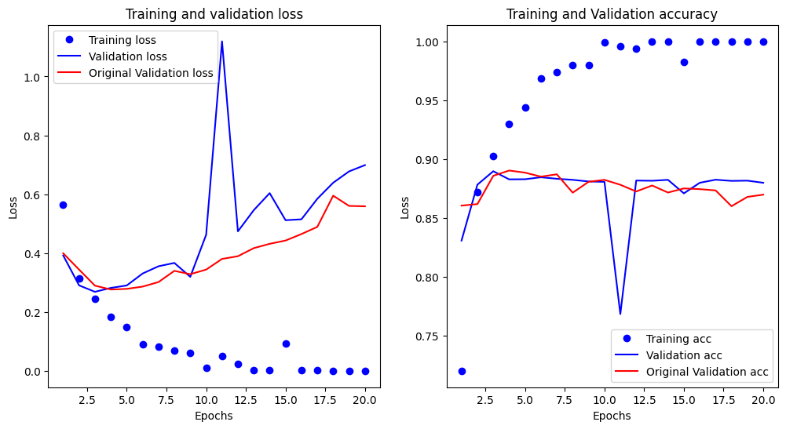

```python
train_model_results('relu','binary_crossentropy', 20, 512, 512 )
```

Now in this part of experimentation , we are going to create two more functions , one for introducing dropout technique that is used to mitigate overfitting and along with that we are going to use Regularization techniques to also see whether they show results in fixing the overfitting issue.

### Dropout

The dropout technique is another technique to reduce or mitigate overfitting. In this technique we basically drop some features in each iteration. Here this can mean either dropping out or setting the features to zero. This is done to make the network rely less on any single feature. The reason this methos works is that switching off some features makes the network more robust, as it cant rely on any specific feature as it might get dropped. Therefore, in the following code I have created a function that adds dropout lines after every layer.

```python
def train_model_results_drop(act_function,loss_function,
                             num_epochs, net_size, batch):
    x_value = x_train[:10000]
    partial_x_train_val = x_train[10000:]
    y_value = y_train[:10000]
    partial_y_train_value = y_train[10000:]
    model = models.Sequential()
    model.add(layers.Dense(net_size,
                           activation=act_function,
                           input_shape=(10000,)))
    model.add(layers.Dropout(0.5))
    model.add(layers.Dense(16, activation=act_function))
    model.add(layers.Dropout(0.5))
    model.add(layers.Dense(1, activation='sigmoid'))
    model.compile(optimizer='rmsprop',
                  loss=loss_function, metrics=['acc'])
    history_drop = model.fit(partial_x_train_val,
                             partial_y_train_value, epochs=num_epochs,
                             batch_size=batch,
                             validation_data=(x_value, y_value))
    results = model.evaluate(x_test, y_test)
    store_results(act_function,loss_function,
                  num_epochs, net_size,batch,
                  results[0], results[1])

    print(
        f'Activation Function : {act_function}Loss Function : {loss_function} Number of Epochs: {num_epochs}'
        )
    print(f'Loss Test : {results[0]} Accuracy Test : {results[1]}')
    plot_results(history_drop)
```

```
30/30 ━━━━━━━━━━━━━━━━━━━━ 2s 49ms/step - acc: 0.5802 - loss: 0.6712 - val_acc: 0.7001 - val_loss: 0.5649
30/30 ━━━━━━━━━━━━━━━━━━━━ 1s 17ms/step - acc: 0.7426 - loss: 0.5688 - val_acc: 0.8594 - val_loss: 0.4739
30/30 ━━━━━━━━━━━━━━━━━━━━ 1s 17ms/step - acc: 0.8208 - loss: 0.4895 - val_acc: 0.8502 - val_loss: 0.4233
30/30 ━━━━━━━━━━━━━━━━━━━━ 1s 16ms/step - acc: 0.8568 - loss: 0.4279 - val_acc: 0.8826 - val_loss: 0.3662
30/30 ━━━━━━━━━━━━━━━━━━━━ 1s 16ms/step - acc: 0.8857 - loss: 0.3680 - val_acc: 0.8815 - val_loss: 0.3488
30/30 ━━━━━━━━━━━━━━━━━━━━ 0s 14ms/step - acc: 0.9009 - loss: 0.3269 - val_acc: 0.8877 - val_loss: 0.3176
30/30 ━━━━━━━━━━━━━━━━━━━━ 1s 15ms/step - acc: 0.9156 - loss: 0.2935 - val_acc: 0.8845 - val_loss: 0.3024
30/30 ━━━━━━━━━━━━━━━━━━━━ 1s 15ms/step - acc: 0.9292 - loss: 0.2589 - val_acc: 0.8864 - val_loss: 0.3037
30/30 ━━━━━━━━━━━━━━━━━━━━ 1s 20ms/step - acc: 0.9346 - loss: 0.2286 - val_acc: 0.8837 - val_loss: 0.2995
30/30 ━━━━━━━━━━━━━━━━━━━━ 1s 31ms/step - acc: 0.9468 - loss: 0.2059 - val_acc: 0.8852 - val_loss: 0.3101
30/30 ━━━━━━━━━━━━━━━━━━━━ 1s 17ms/step - acc: 0.9542 - loss: 0.1794 - val_acc: 0.8831 - val_loss: 0.3201
30/30 ━━━━━━━━━━━━━━━━━━━━ 0s 14ms/step - acc: 0.9540 - loss: 0.1627 - val_acc: 0.8828 - val_loss: 0.3332
30/30 ━━━━━━━━━━━━━━━━━━━━ 0s 15ms/step - acc: 0.9611 - loss: 0.1463 - val_acc: 0.8839 - val_loss: 0.3921
30/30 ━━━━━━━━━━━━━━━━━━━━ 0s 13ms/step - acc: 0.9612 - loss: 0.1351 - val_acc: 0.8837 - val_loss: 0.4111
30/30 ━━━━━━━━━━━━━━━━━━━━ 0s 15ms/step - acc: 0.9683 - loss: 0.1183 - val_acc: 0.8827 - val_loss: 0.4187
30/30 ━━━━━━━━━━━━━━━━━━━━ 0s 14ms/step - acc: 0.9730 - loss: 0.1078 - val_acc: 0.8786 - val_loss: 0.4096
30/30 ━━━━━━━━━━━━━━━━━━━━ 0s 12ms/step - acc: 0.9718 - loss: 0.1034 - val_acc: 0.8815 - val_loss: 0.4764
30/30 ━━━━━━━━━━━━━━━━━━━━ 0s 11ms/step - acc: 0.9757 - loss: 0.0882 - val_acc: 0.8804 - val_loss: 0.5308
30/30 ━━━━━━━━━━━━━━━━━━━━ 0s 13ms/step - acc: 0.9786 - loss: 0.0826 - val_acc: 0.8804 - val_loss: 0.4826
30/30 ━━━━━━━━━━━━━━━━━━━━ 0s 14ms/step - acc: 0.9801 - loss: 0.0739 - val_acc: 0.8784 - val_loss: 0.6297
782/782 ━━━━━━━━━━━━━━━━━━━━ 1s 748us/step - acc: 0.8677 - loss: 0.6669
Activation Function : relu Loss Function : binary_crossentropy Number of Epochs: 20
Loss Test : 0.6436851620674133 Accuracy Test : 0.8711199760437012
```

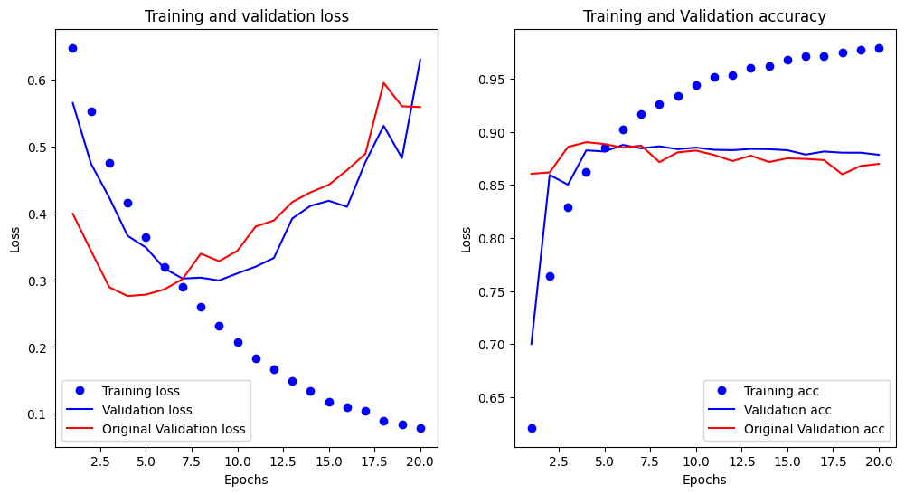

```python
train_model_results_drop('relu','binary_crossentropy', 20, 16, 512 )
```

```
30/30 ━━━━━━━━━━━━━━━━━━━━ 2s 41ms/step - acc: 0.5992 - loss: 0.6553 - val_acc: 0.8451 - val_loss: 0.4939
30/30 ━━━━━━━━━━━━━━━━━━━━ 1s 16ms/step - acc: 0.7624 - loss: 0.5060 - val_acc: 0.8747 - val_loss: 0.4058
30/30 ━━━━━━━━━━━━━━━━━━━━ 0s 15ms/step - acc: 0.8288 - loss: 0.4193 - val_acc: 0.8846 - val_loss: 0.3428
30/30 ━━━━━━━━━━━━━━━━━━━━ 0s 14ms/step - acc: 0.8594 - loss: 0.3699 - val_acc: 0.8868 - val_loss: 0.3051
30/30 ━━━━━━━━━━━━━━━━━━━━ 0s 14ms/step - acc: 0.8820 - loss: 0.3299 - val_acc: 0.8886 - val_loss: 0.2913
30/30 ━━━━━━━━━━━━━━━━━━━━ 0s 13ms/step - acc: 0.9072 - loss: 0.2773 - val_acc: 0.8861 - val_loss: 0.2921
30/30 ━━━━━━━━━━━━━━━━━━━━ 0s 13ms/step - acc: 0.9177 - loss: 0.2474 - val_acc: 0.8863 - val_loss: 0.2826
782/782 ━━━━━━━━━━━━━━━━━━━━ 1s 703us/step - acc: 0.8765 - loss: 0.3009
Activation Function : relu Loss Function : binary_crossentropy Number of Epochs: 7
Loss Test : 0.2988828122615814 Accuracy Test : 0.8781200051307678
```

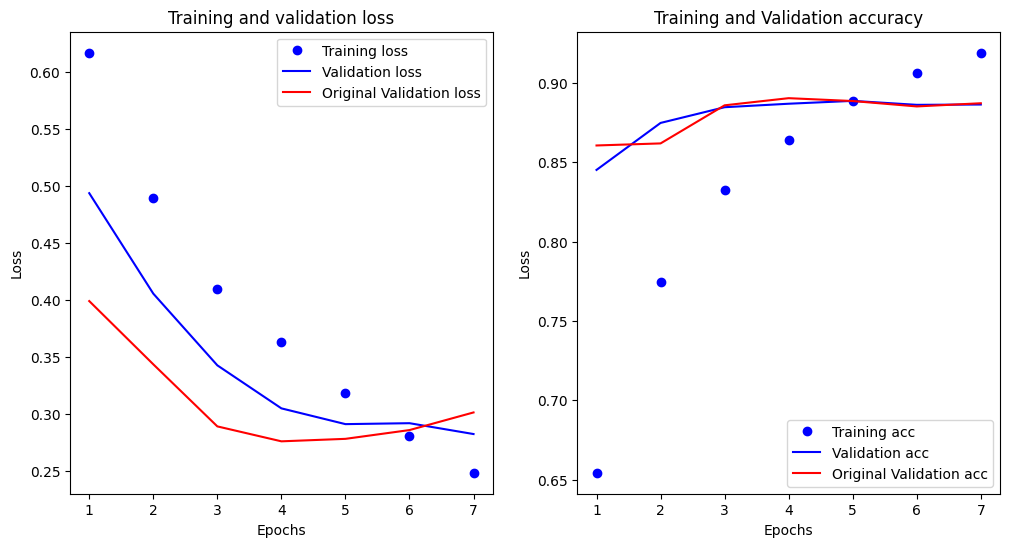

```python
train_model_results_drop('relu','binary_crossentropy', 7, 16, 512 )
```

### Adding L2 Weight Regularization to the model

Regularization is one of the popular techniques to mitigate overfitting. In regularization we add penalties for the weights of the network. In L2 regularization specifically, we do this by limiting the weights to not take large values, this ensures even distribution of values.

```python
from keras import regularizers

def train_model_results_l2(act_function,loss_function,
                           num_epochs, net_size, batch):
    x_value = x_train[:10000]
    partial_x_train_val = x_train[10000:]
    y_value = y_train[:10000]
    partial_y_train_value = y_train[10000:]
    model = models.Sequential()
    model.add(layers.Dense(net_size, kernel_regularizer=regularizers.l2(0.001),
                        activation=act_function, input_shape=(10000,)))
    model.add(layers.Dense(net_size, kernel_regularizer=regularizers.l2(0.001),
                        activation=act_function))
    model.add(layers.Dense(1, activation='sigmoid'))
    model.compile(optimizer='rmsprop', loss=loss_function, metrics=['acc'])
    history_l2 = model.fit(partial_x_train_val, partial_y_train_value,
                           epochs=num_epochs, batch_size=batch,
                           validation_data=(x_value, y_value))
    results = model.evaluate(x_test, y_test)
    store_results(act_function,loss_function,
                  num_epochs, net_size,batch,
                  results[0], results[1])

    print(f'Activation Function : {act_function} Loss Function : {loss_function} Number of Epochs: {num_epochs}')
    print(f'Loss Test : {results[0]} Accuracy Test : {results[1]}')
    plot_results(history_l2)
```

#### Testing the function and comparing the results to the original network.

```
30/30 ━━━━━━━━━━━━━━━━━━━━ 2s 44ms/step - acc: 0.6634 - loss: 0.6772 - val_acc: 0.8546 - val_loss: 0.4953
30/30 ━━━━━━━━━━━━━━━━━━━━ 0s 12ms/step - acc: 0.8809 - loss: 0.4396 - val_acc: 0.8741 - val_loss: 0.3939
30/30 ━━━━━━━━━━━━━━━━━━━━ 0s 9ms/step - acc: 0.9022 - loss: 0.3402 - val_acc: 0.8860 - val_loss: 0.3500
30/30 ━━━━━━━━━━━━━━━━━━━━ 0s 13ms/step - acc: 0.9232 - loss: 0.2841 - val_acc: 0.8866 - val_loss: 0.3355
30/30 ━━━━━━━━━━━━━━━━━━━━ 0s 15ms/step - acc: 0.9345 - loss: 0.2545 - val_acc: 0.8880 - val_loss: 0.3317
30/30 ━━━━━━━━━━━━━━━━━━━━ 1s 16ms/step - acc: 0.9443 - loss: 0.2332 - val_acc: 0.8846 - val_loss: 0.3325
30/30 ━━━━━━━━━━━━━━━━━━━━ 0s 13ms/step - acc: 0.9459 - loss: 0.2178 - val_acc: 0.8820 - val_loss: 0.3505
30/30 ━━━━━━━━━━━━━━━━━━━━ 1s 17ms/step - acc: 0.9561 - loss: 0.2006 - val_acc: 0.8774 - val_loss: 0.3687
30/30 ━━━━━━━━━━━━━━━━━━━━ 1s 15ms/step - acc: 0.9575 - loss: 0.1979 - val_acc: 0.8829 - val_loss: 0.3525
30/30 ━━━━━━━━━━━━━━━━━━━━ 0s 13ms/step - acc: 0.9640 - loss: 0.1837 - val_acc: 0.8816 - val_loss: 0.3607
30/30 ━━━━━━━━━━━━━━━━━━━━ 0s 9ms/step - acc: 0.9675 - loss: 0.1763 - val_acc: 0.8790 - val_loss: 0.3675
30/30 ━━━━━━━━━━━━━━━━━━━━ 0s 10ms/step - acc: 0.9724 - loss: 0.1655 - val_acc: 0.8803 - val_loss: 0.3736
30/30 ━━━━━━━━━━━━━━━━━━━━ 0s 10ms/step - acc: 0.9765 - loss: 0.1588 - val_acc: 0.8621 - val_loss: 0.4257
30/30 ━━━━━━━━━━━━━━━━━━━━ 0s 10ms/step - acc: 0.9645 - loss: 0.1726 - val_acc: 0.8768 - val_loss: 0.3913
30/30 ━━━━━━━━━━━━━━━━━━━━ 0s 11ms/step - acc: 0.9751 - loss: 0.1542 - val_acc: 0.8683 - val_loss: 0.4337
30/30 ━━━━━━━━━━━━━━━━━━━━ 0s 10ms/step - acc: 0.9726 - loss: 0.1559 - val_acc: 0.8700 - val_loss: 0.4144
30/30 ━━━━━━━━━━━━━━━━━━━━ 0s 11ms/step - acc: 0.9770 - loss: 0.1487 - val_acc: 0.8749 - val_loss: 0.4108
30/30 ━━━━━━━━━━━━━━━━━━━━ 1s 27ms/step - acc: 0.9815 - loss: 0.1417 - val_acc: 0.8751 - val_loss: 0.4144
30/30 ━━━━━━━━━━━━━━━━━━━━ 1s 14ms/step - acc: 0.9795 - loss: 0.1425 - val_acc: 0.8718 - val_loss: 0.4239
30/30 ━━━━━━━━━━━━━━━━━━━━ 1s 20ms/step - acc: 0.9822 - loss: 0.1380 - val_acc: 0.8710 - val_loss: 0.4311
782/782 ━━━━━━━━━━━━━━━━━━━━ 1s 1ms/step - acc: 0.8593 - loss: 0.4607
Activation Function : relu Loss Function : binary_crossentropy Number of Epochs: 20
Loss Test : 0.45625975728034973 Accuracy Test : 0.8628000020980835
```

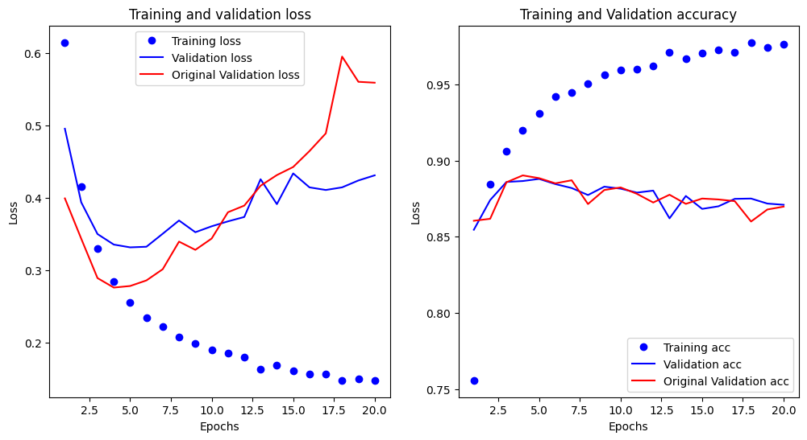

```python
train_model_results_l2('relu','binary_crossentropy', 20, 16, 512 )
```

### Comparing the results

```python
import pandas as pd
#creating a dataframe for the results that we have been storing
all_results_df = pd.DataFrame(model_results)
sorted_results_df = all_results_df.sort_values(by=['Loss'], ascending=True)
display(sorted_results_df)
```

|  | Loss function | Activation | Epochs | Network Size | Batch Size | Loss | Accuracy |
| --- | --- | --- | --- | --- | --- | --- | --- |
| 4 | mean_squared_error | relu | 4 | 16 | 512 | 0.090765 | 0.88308 |
| 3 | mean_squared_error | tanh | 20 | 16 | 512 | 0.118641 | 0.86128 |
| 9 | binary_crossentropy | relu | 7 | 16 | 512 | 0.298883 | 0.87812 |
| 5 | binary_crossentropy | relu | 20 | 4 | 512 | 0.414241 | 0.86356 |
| 2 | binary_crossentropy | relu | 20 | 16 | 1024 | 0.416484 | 0.85580 |
| 10 | binary_crossentropy | relu | 20 | 16 | 512 | 0.456260 | 0.86280 |
| 6 | binary_crossentropy | relu | 20 | 16 | 512 | 0.563120 | 0.86092 |
| 0 | binary_crossentropy | relu | 20 | 16 | 512 | 0.572569 | 0.86048 |
| 8 | binary_crossentropy | relu | 20 | 16 | 512 | 0.643685 | 0.87112 |
| 7 | binary_crossentropy | relu | 20 | 512 | 512 | 0.737292 | 0.87408 |
| 1 | binary_crossentropy | relu | 20 | 16 | 128 | 1.398565 | 0.85004 |

After comparing the results, the table above shows results from all the comparisons that we have done. We can see that all experiments produced similar accuracies. However the validation loss has been fluctuating in every experience. As the table has the experiments sorted by the least loss to the highest one. It shows that using 4 epochs provided us with the best loss value.

## Conclusion

The project above works extensively on IMDB moviw reviews dataset. The project starts by working on the dataset and getting the dataset ready for using it as an input. Then the project builts a network by picking suitable loss and activation function and builds a network. The project then validates the network by assesing the network for validation loss and accuracy. The project then further works on exploring techniques that are used for reducing overfitting. These techniques include changing hyperparameters and similarly, using techniques like regularization and dropout. Finally the project uses the observation of graphs and the dataset collected to see which combination and techniques affected the accuracy and precision. I was concluded that all techniques were able to get similar accuracy however, the mean_squared error loss function along with relu function provided with the lowest validation loss and highest accuracy.

# References

### creating side by side graphs for model result function

- Tutorialspoint. (n.d.). How to make two plots side-by-side using Python?. Retrieved March 10, 2024, from https://www.tutorialspoint.com/how-to-make-two-plots-side-by-side-using-python

### Code snippets used in the report ar taken from the book

The code has been modified at alot of places but the source of the code is from this book, the basic implimentation of the deep learning process carried out in chapter 3: IMDB Dataset is used to work on this report.

- Chollet, F. (2017). Deep Learning with Python. Manning Publications.